# iLykei Lecture Series Machine Learning Regularized Regression Workshop: Selecting/Eliminating Predictors using Regularization Methods

Yuri Balasanov, © iLykei 2015-2023

# 1 Regularization

Make simulated data for illustration of regularization method.

1. Create a function $Y(X)$ that needs to be minimized and find its minimum.

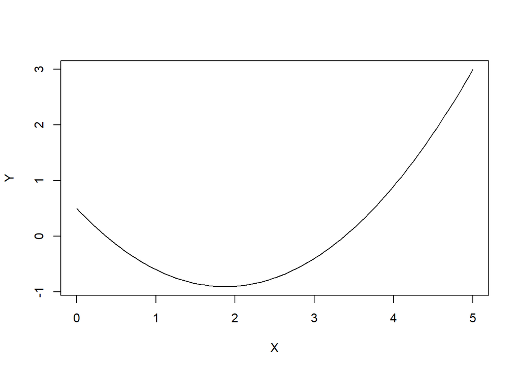

```r
X<-seq(0,5,length=100)
Y<-.5-1.5*X+.4*X^2
plot(X,Y,type="l")
```

```r
(act.min<-X[which.min(Y)])
```

```
## [1] 1.868687
```

2. Add a little noise to the function.

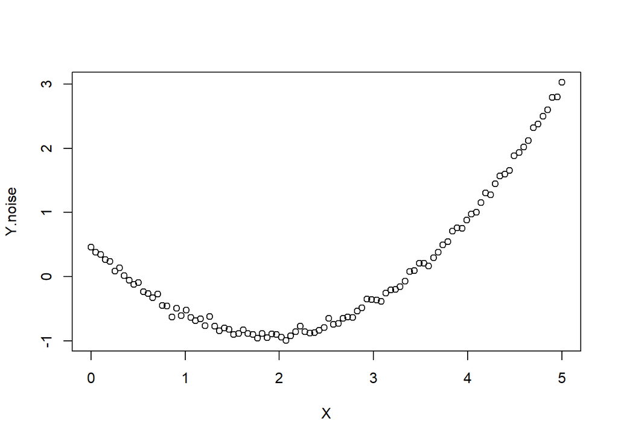

```r
set.seed(9)
Eps<-rnorm(length(X),0,.05)
Y.noise<-Y+Eps
plot(X,Y.noise)
```

```r
(obs.min<-X[which.min(Y.noise)])
```

```
## [1] 2.070707
```

Even a little noise may change minimum of the observed data.

3. Apply ideal regularizator to make search for minimum more stable:
   $$\alpha=0.5-1.5 X +0.4 X^2,$$
   where function $\alpha(X)$ is represented by variable `regularizator`.

```r
regularizator<-.5-1.5*X+.4*X^2
```

This regularizator is ideal because it “knows” the exact function.

Select tuning parameter $\lambda$ represented by variable `tune` and minimize function
$$Y(X)+\lambda \alpha(X)$$
instead of $Y(X)$.

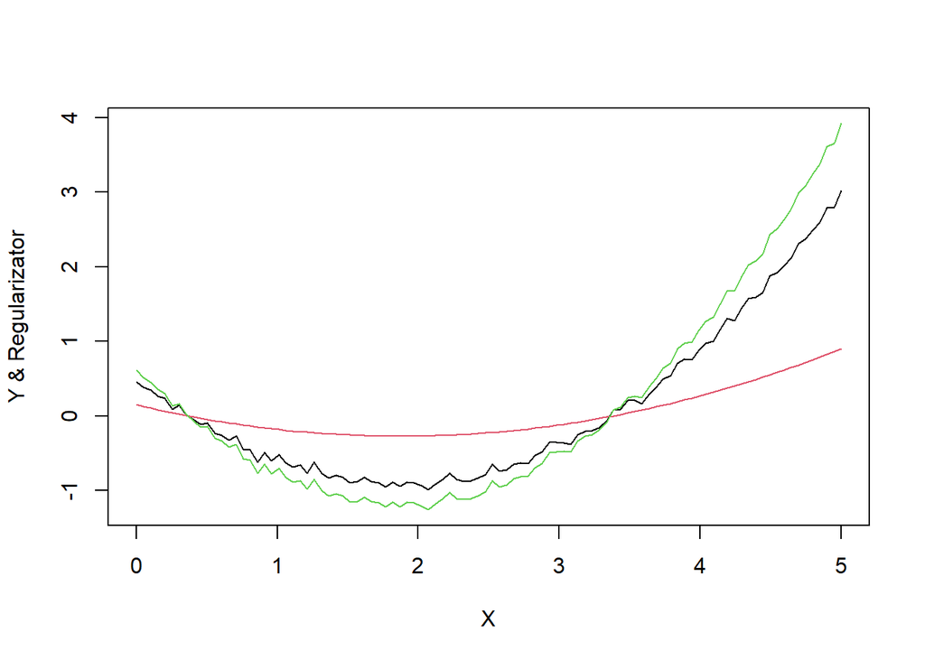

```r
tune<-.3
matplot(X,cbind(Y.noise,regularizator*tune,Y.noise+regularizator*tune),type="l",lty=1,ylab="Y & Regularizator")
```

```r
(reg.min.3<-X[which.min(Y.noise+regularizator*.3)])
```

```
## [1] 2.070707
```

Setting tuning parameter to 0.3 did not help finding the real minimum of $Y(X)$.

Increase the tuning parameter to 1.

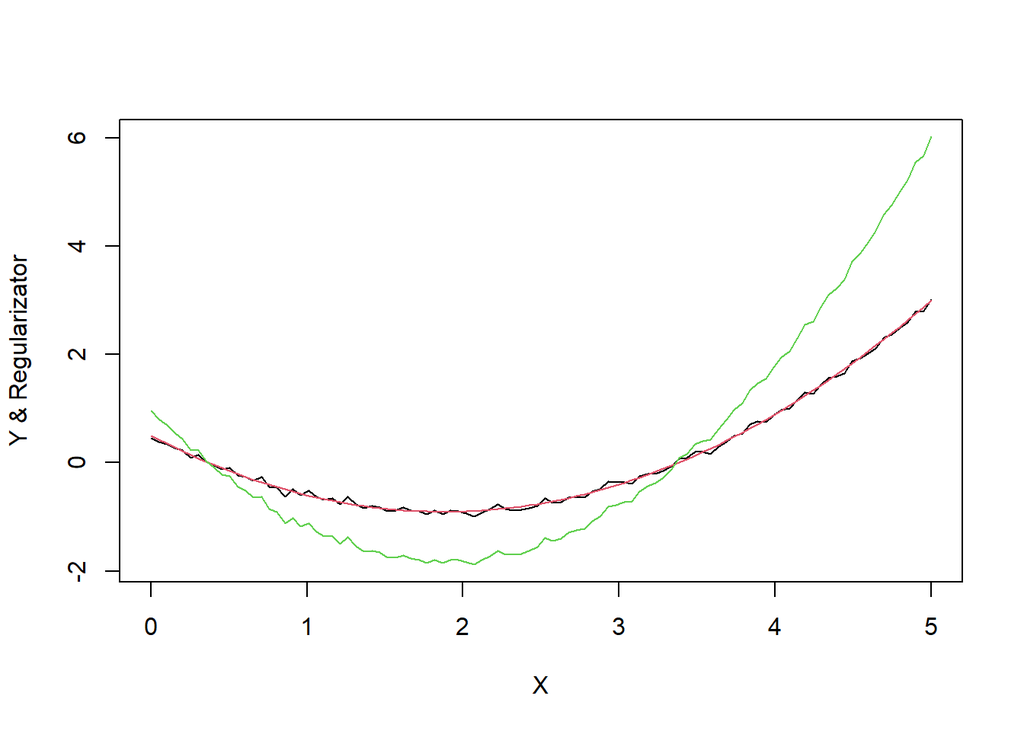

```r
tune<-1
matplot(X,cbind(Y.noise,regularizator*tune,Y.noise+regularizator*tune),type="l",lty=1,ylab="Y & Regularizator")
```

```r
(reg.min.1.0<-X[which.min(Y.noise+regularizator*tune)])
```

```
## [1] 2.070707
```

Still real minimum of $Y(X)$ is overestimated.

Increase tuning parameter to 3.

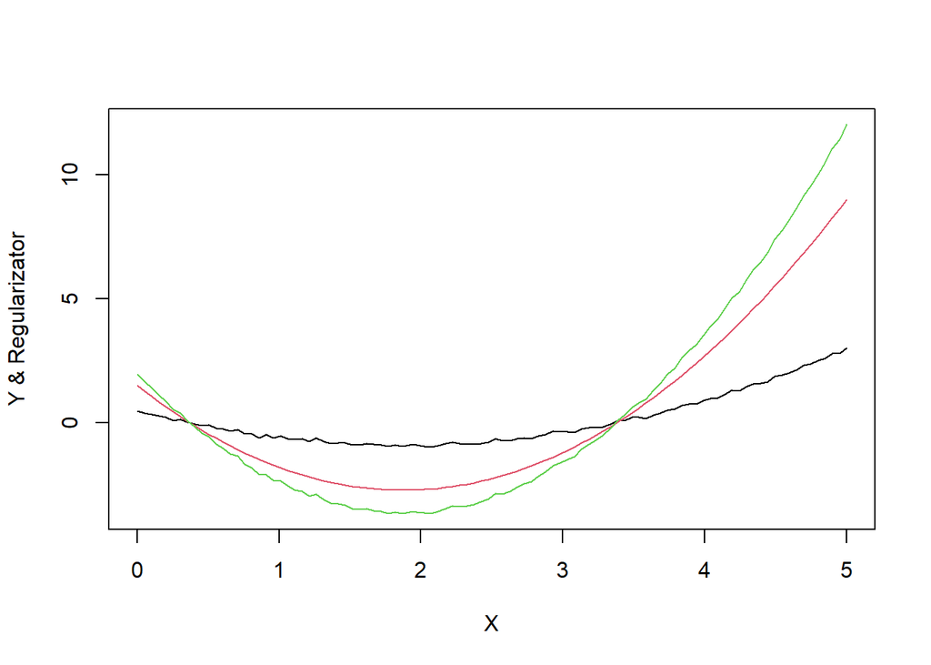

```r
tune<-3
matplot(X,cbind(Y.noise,regularizator*tune,Y.noise+regularizator*tune),type="l",lty=1,ylab="Y & Regularizator")
```

```r
(reg.min.2.0<-X[which.min(Y.noise+regularizator*tune)])
```

```
## [1] 1.868687
```

Now regularization worked: we recovered the actual minimum of the function.

But in real life we do not know ideal regularizator.
What if we set regularizator with a little shift in one of the coefficients?
Consider regularizator
$$\alpha(X)=
.5-1.5X+.3X^2,$$
changing the third coefficient to 0.3 instead of 0.4.

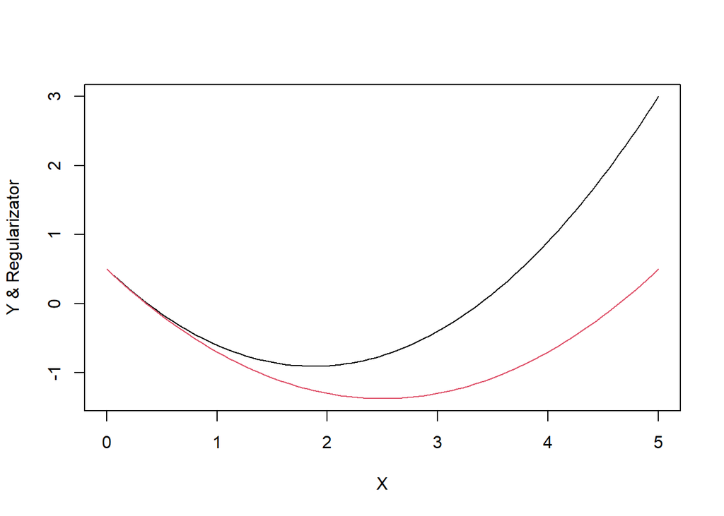

```r
biasedRegularizator<-.5-1.5*X+.3*X^2
matplot(X,cbind(Y,biasedRegularizator),type="l",lty=1,ylab="Y & Regularizator")
```

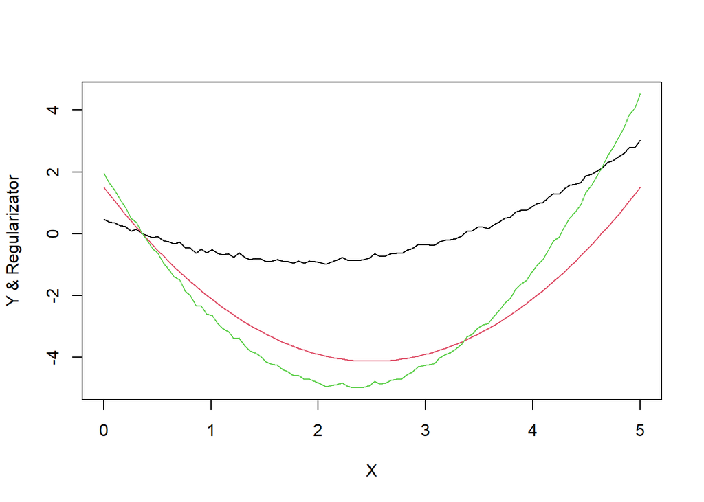

```r
matplot(X,cbind(Y.noise,biasedRegularizator*tune,Y.noise+biasedRegularizator*tune),type="l",lty=1,ylab="Y & Regularizator")
```

```r
(biasedReg.min.2.0<-X[which.min(Y.noise+biasedRegularizator*tune)])
```

```
## [1] 2.373737
```

**Lessons:**  
1. Regularization is a very powerful method that allows using additional information about the solution of the problem.  
2. If there is no significant additional information then regularization can be misleading.  
3. When applied to regression without additional knowledge about parameters the problem of bias in the parameters and increased variance of their estimators is replaced by the same issues, but in regularizator.

# 2 Lasso Regression

## 2.1 Prostate data example

### 2.1.1 Prepare the data

```r
library(glmnet)
```

Read the data from prostate cancer study described in Elements of Statistical Learning: Data Mining, Inference and Prediction (second Edition), T.Hastie, R.Tibshirani, J. Friedman,2008, Springer.  
Data and other supplemental materials are on the [website of the book](http://statweb.stanford.edu/~tibs/ElemStatLearn/)

```r
prostateData<-read.csv(file=paste(datapath,"prostatedata.csv",sep="/"))
head(prostateData)
```

```
##       lcavol  lweight age      lbph svi       lcp gleason pgg45       lpsa
## 1 -0.5798185 2.769459  50 -1.386294   0 -1.386294       6     0 -0.4307829
## 2 -0.9942523 3.319626  58 -1.386294   0 -1.386294       6     0 -0.1625189
## 3 -0.5108256 2.691243  74 -1.386294   0 -1.386294       7    20 -0.1625189
## 4 -1.2039728 3.282789  58 -1.386294   0 -1.386294       6     0 -0.1625189
## 5  0.7514161 3.432373  62 -1.386294   0 -1.386294       6     0  0.3715636
## 6 -1.0498221 3.228826  50 -1.386294   0 -1.386294       6     0  0.7654678
##   train
## 1  TRUE
## 2  TRUE
## 3  TRUE
## 4  TRUE
## 5  TRUE
## 6  TRUE
```

The goal of the study was to examine correlation between log of prostate-specific antigen `lpsa` as an output and some clinical measures:

- Log cancer volume `lcavol`
- Log prostate weight `lweight`
- Age `age`
- Log of the amount of benign prostatic hyperplasia `lbph`
- Seminal vehicle invasion `svi`
- Log of capsular penetration `lcp`
- Gleason score `gleason`
- percent of Gleason scores 4 or 5 `pgg45`

The last column in the file shows which rows were randomly selected for train sample and which for test sample.

Separate the train sub-sample and normalize the predictors.

```r
prostateData.norm<-prostateData
prostateData.norm[,1:8]<-apply(prostateData.norm[,-c(9,10)],2,function(z) z/sd(z))
apply(prostateData.norm[,1:8],2,function(z) sd(z))
```

```
##  lcavol lweight     age    lbph     svi     lcp gleason   pgg45
##       1       1       1       1       1       1       1       1
```

```r
prostateData.norm.train<-prostateData.norm[prostateData.norm$train,]
head(prostateData.norm.train)
```

```
##       lcavol  lweight      age       lbph svi        lcp  gleason     pgg45
## 1 -0.4919449 6.464487 6.715811 -0.9555335   0 -0.9914498 8.308706 0.0000000
## 2 -0.8435697 7.748690 7.790341 -0.9555335   0 -0.9914498 8.308706 0.0000000
## 3 -0.4334081 6.281915 9.939400 -0.9555335   0 -0.9914498 9.693490 0.7091184
## 4 -1.0215064 7.662705 7.790341 -0.9555335   0 -0.9914498 8.308706 0.0000000
## 5  0.6375363 8.011865 8.327606 -0.9555335   0 -0.9914498 8.308706 0.0000000
## 6 -0.8907178 7.536745 6.715811 -0.9555335   0 -0.9914498 8.308706 0.0000000
##         lpsa train
## 1 -0.4307829  TRUE
## 2 -0.1625189  TRUE
## 3 -0.1625189  TRUE
## 4 -0.1625189  TRUE
## 5  0.3715636  TRUE
## 6  0.7654678  TRUE
```

```r
prostateData.norm.test<-prostateData.norm[!prostateData.norm$train,]
head(prostateData.norm.test)
```

```
##        lcavol  lweight      age       lbph svi        lcp  gleason     pgg45
## 7   0.6254442 8.107906 8.596238  0.4240301   0 -0.9914498 8.308706 0.0000000
## 9  -0.6588430 8.261943 6.312862 -0.9555335   0 -0.9914498 8.308706 0.0000000
## 10  0.1893253 7.573434 8.461922 -0.9555335   0 -0.9914498 8.308706 0.0000000
## 15  1.0232016 8.034381 7.656025 -0.9555335   0 -0.3080873 9.693490 0.1772796
## 22  1.7471537 8.172155 8.058973  1.0165125   0  0.9641148 9.693490 0.7091184
## 25  0.3268745 8.560467 9.267819  1.1024127   0 -0.9914498 8.308706 0.0000000
##         lpsa train
## 7  0.7654678 FALSE
## 9  1.0473190 FALSE
## 10 1.0473190 FALSE
## 15 1.3987169 FALSE
## 22 1.6582281 FALSE
## 25 1.7316555 FALSE
```

```r
length(prostateData.norm.train$train)
```

```
## [1] 67
```

```r
length(prostateData.norm.test$train)
```

```
## [1] 30
```

### 2.1.2 Fitting linear model

Fit linear model.

```r
allPredictors.lm<-lm(lpsa~.,data=prostateData.norm.train[,-10])
summary(allPredictors.lm)
```

```
##
## Call:
## lm(formula = lpsa ~ ., data = prostateData.norm.train[, -10])
##
## Residuals:
##      Min       1Q   Median       3Q      Max
## -1.64870 -0.34147 -0.05424  0.44941  1.48675
##
## Coefficients:
##             Estimate Std. Error t value Pr(>|t|)
## (Intercept)  0.42917    1.55359   0.276  0.78334
## lcavol       0.67953    0.12663   5.366 1.47e-06 ***
## lweight      0.26305    0.09563   2.751  0.00792 **
## age         -0.14146    0.10134  -1.396  0.16806
## lbph         0.21015    0.10222   2.056  0.04431 *
## svi          0.30520    0.12360   2.469  0.01651 *
## lcp         -0.28849    0.15453  -1.867  0.06697 .
## gleason     -0.02131    0.14525  -0.147  0.88389
## pgg45        0.26696    0.15361   1.738  0.08755 .
## ---
## Signif. codes:  0 '***' 0.001 '**' 0.01 '*' 0.05 '.' 0.1 ' ' 1
##
## Residual standard error: 0.7123 on 58 degrees of freedom
## Multiple R-squared:  0.6944, Adjusted R-squared:  0.6522
## F-statistic: 16.47 on 8 and 58 DF,  p-value: 2.042e-12
```

Check correlations between predictors.

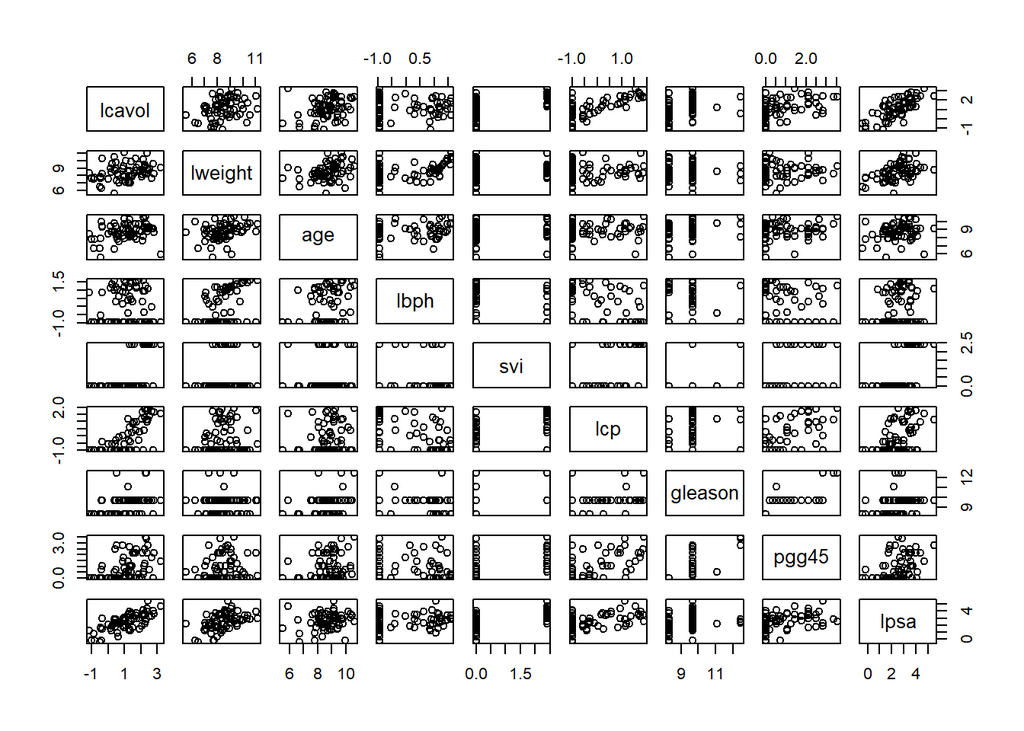

```r
pairs(prostateData.norm.train[,-c(10)])
```

```r
cor(prostateData.norm.train[,-c(9,10)])
```

```
##             lcavol    lweight       age        lbph        svi         lcp
## lcavol  1.00000000 0.30023199 0.2863243  0.06316772  0.5929491  0.69204308
## lweight 0.30023199 1.00000000 0.3167235  0.43704154  0.1810545  0.15682859
## age     0.28632427 0.31672347 1.0000000  0.28734645  0.1289023  0.17295140
## lbph    0.06316772 0.43704154 0.2873464  1.00000000 -0.1391468 -0.08853456
## svi     0.59294913 0.18105448 0.1289023 -0.13914680  1.0000000  0.67124021
## lcp     0.69204308 0.15682859 0.1729514 -0.08853456  0.6712402  1.00000000
## gleason 0.42641407 0.02355821 0.3659151  0.03299215  0.3068754  0.47643684
## pgg45   0.48316136 0.07416632 0.2758057 -0.03040382  0.4813577  0.66253335
##            gleason       pgg45
## lcavol  0.42641407  0.48316136
## lweight 0.02355821  0.07416632
## age     0.36591512  0.27580573
## lbph    0.03299215 -0.03040382
## svi     0.30687537  0.48135774
## lcp     0.47643684  0.66253335
## gleason 1.00000000  0.75705650
## pgg45   0.75705650  1.00000000
```

```r
cor(prostateData.norm.train[,-c(9,10)])^2
```

```
##              lcavol      lweight        age         lbph        svi         lcp
## lcavol  1.000000000 0.0901392460 0.08198159 0.0039901609 0.35158867 0.478923618
## lweight 0.090139246 1.0000000000 0.10031376 0.1910053047 0.03278072 0.024595208
## age     0.081981585 0.1003137554 1.00000000 0.0825679799 0.01661579 0.029912186
## lbph    0.003990161 0.1910053047 0.08256798 1.0000000000 0.01936183 0.007838368
## svi     0.351588671 0.0327807241 0.01661579 0.0193618317 1.00000000 0.450563420
## lcp     0.478923618 0.0245952081 0.02991219 0.0078383682 0.45056342 1.000000000
## gleason 0.181828961 0.0005549891 0.13389388 0.0010884821 0.09417249 0.226992058
## pgg45   0.233444897 0.0055006431 0.07606880 0.0009243922 0.23170527 0.438950442
##              gleason        pgg45
## lcavol  0.1818289612 0.2334448970
## lweight 0.0005549891 0.0055006431
## age     0.1338938769 0.0760688002
## lbph    0.0010884821 0.0009243922
## svi     0.0941724942 0.2317052748
## lcp     0.2269920584 0.4389504419
## gleason 1.0000000000 0.5731345387
## pgg45   0.5731345387 1.0000000000
```

```r
cor(prostateData.norm.train[,-c(9,10)])^2>.5
```

```
##         lcavol lweight   age  lbph   svi   lcp gleason pgg45
## lcavol    TRUE   FALSE FALSE FALSE FALSE FALSE   FALSE FALSE
## lweight  FALSE    TRUE FALSE FALSE FALSE FALSE   FALSE FALSE
## age      FALSE   FALSE  TRUE FALSE FALSE FALSE   FALSE FALSE
## lbph     FALSE   FALSE FALSE  TRUE FALSE FALSE   FALSE FALSE
## svi      FALSE   FALSE FALSE FALSE  TRUE FALSE   FALSE FALSE
## lcp      FALSE   FALSE FALSE FALSE FALSE  TRUE   FALSE FALSE
## gleason  FALSE   FALSE FALSE FALSE FALSE FALSE    TRUE  TRUE
## pgg45    FALSE   FALSE FALSE FALSE FALSE FALSE    TRUE  TRUE
```

Matrix of determination coefficients shows that there is one significant determination coefficient (>0.5) between predictors: $\rho^2(ppg45,gleason)=0.573$.  
The other three noticeable determination coefficients are $\rho^2(lcp,lcavol)=0.479$, $\rho^2(lcp,svi)=0.45$ and $\rho^2(lcp,pgg45)=0.439.$

Correlations between predictors make selection of predictors difficult.  
For example, predictor `lcp` is correlated with `lcavol`, `svi` and `pgg45`.  
In the presence of all predictors `svi` is significant with 5% level, but `lcp` is not.

```r
summary(allPredictors.lm)$coefficients[,4]>.05 #all: age, lcp, gleason, pgg45
```

```
## (Intercept)      lcavol     lweight         age        lbph         svi
##        TRUE       FALSE       FALSE        TRUE       FALSE       FALSE
##         lcp     gleason       pgg45
##        TRUE        TRUE        TRUE
```

But after removal of `lcp` predictor `svi` becomes insignificant.

```r
nolcp.lm<-lm(lpsa~lcavol+lweight+age+lbph+svi+gleason+pgg45,data=prostateData.norm.train[,-10])
summary(nolcp.lm)$coefficients[,4]>.05 #no lcp: age, svi,gleason, pgg45
```

```
## (Intercept)      lcavol     lweight         age        lbph         svi
##        TRUE       FALSE       FALSE        TRUE       FALSE        TRUE
##     gleason       pgg45
##        TRUE        TRUE
```

This is a big challenge for any greedy algorithm.

Consider removing all insignificant predictors: `age`, `lcp`, `gleason` and `pgg45`.

We can test significance of groups of predictors by using F-statistic
$$F=\frac{(RSS_0-RSS_1)/(p_1-p_0)}{RSS_1/(N-p_1-1)},$$
where $RSS_1$ is the residual sum of squares of bigger model including all $p_1+1$ parameters $\beta_0,\beta_1,\ldots,\beta_{p_1}$; $RSS_0$ is the residual sum of squares of the model that has only $p_0+1$ parameters not equal to zero and the rest $p_1-p_0$ parameters equal to zero: $\beta_0,\beta_1,\ldots,\beta_{p_0},\beta_{p_0+1}=0,\ldots,\beta_{p_1}=0$.
Such F-statistic measures significance of change in sum of squares of the bigger model if a group of predictors gets eliminated.
Under $H_0:\beta_{p_0+1}=0,\ldots,\beta_{p_1}=0$ the statistic has F-distribution: $F \sim F_{p_1-p_0,N-{p_1}-1}$.

```r
significantPredictors.lm<-lm(lpsa~lcavol+lweight+lbph+svi,data=prostateData.norm.train[,-10])

(RSS1<-sum(allPredictors.lm$residuals^2))
```

```
## [1] 29.42638
```

```r
(RSS0<-sum(significantPredictors.lm$residuals^2))
```

```
## [1] 32.81499
```

```r
(statisticF<-(RSS0-RSS1)/(8-4)/RSS1*(67-9))
```

```
## [1] 1.669755
```

```r
1-pf(statisticF,4,67-9)
```

```
## [1] 0.1693371
```

This shows that p-value is large and $H_0:\beta_{p_0+1}=0,\ldots,\beta_{p_1}=0$ cannot be rejected.

Check assumptions of the model and mean square error of prediction of `significantPredictors.lm`.

```r
summary(significantPredictors.lm)
```

```
##
## Call:
## lm(formula = lpsa ~ lcavol + lweight + lbph + svi, data = prostateData.norm.train[,
##     -10])
##
## Residuals:
##     Min      1Q  Median      3Q     Max
## -1.8709 -0.3903 -0.0172  0.5676  1.4227
##
## Coefficients:
##             Estimate Std. Error t value Pr(>|t|)
## (Intercept) -0.32592    0.77998  -0.418   0.6775
## lcavol       0.59582    0.10910   5.461 8.85e-07 ***
## lweight      0.23084    0.09456   2.441   0.0175 *
## lbph         0.20313    0.10215   1.988   0.0512 .
## svi          0.27814    0.11311   2.459   0.0167 *
## ---
## Signif. codes:  0 '***' 0.001 '**' 0.01 '*' 0.05 '.' 0.1 ' ' 1
##
## Residual standard error: 0.7275 on 62 degrees of freedom
## Multiple R-squared:  0.6592, Adjusted R-squared:  0.6372
## F-statistic: 29.98 on 4 and 62 DF,  p-value: 6.911e-14
```

Note that `lbph` is still not significant with 5% level.

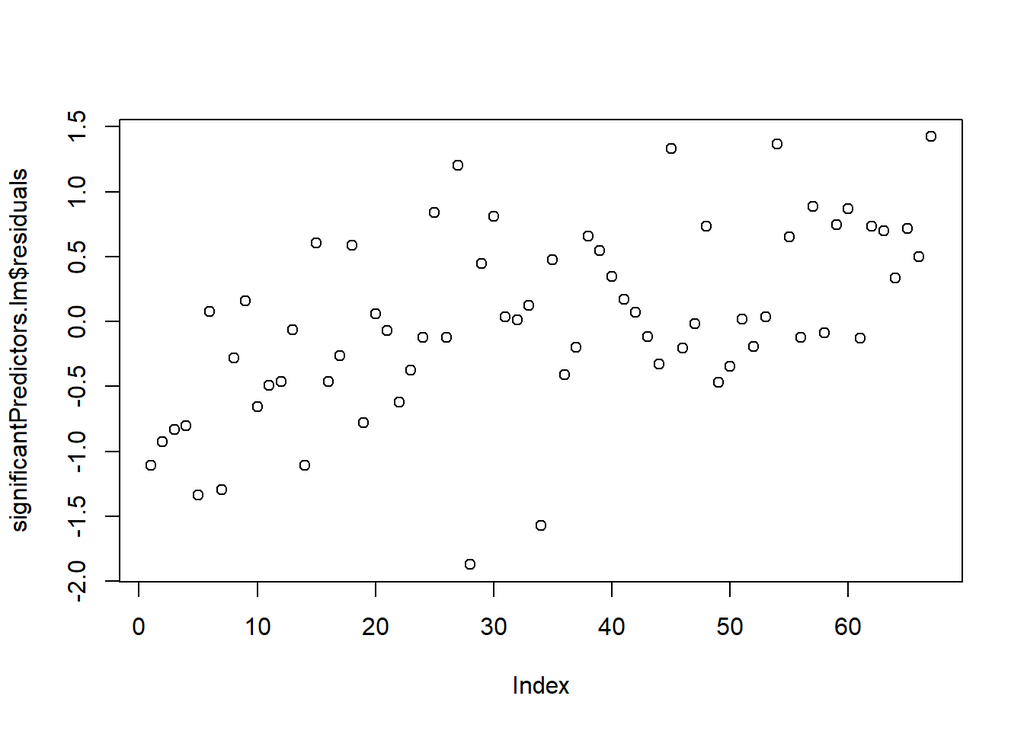

```r
plot(significantPredictors.lm$residuals)
```

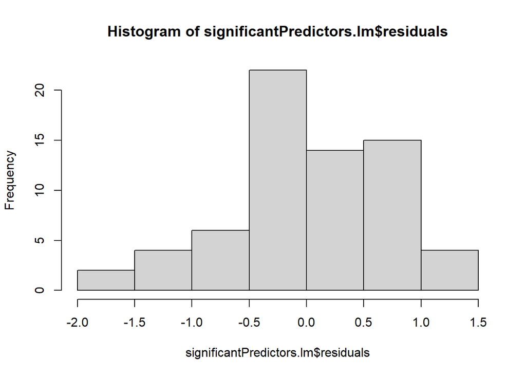

```r
hist(significantPredictors.lm$residuals)
```

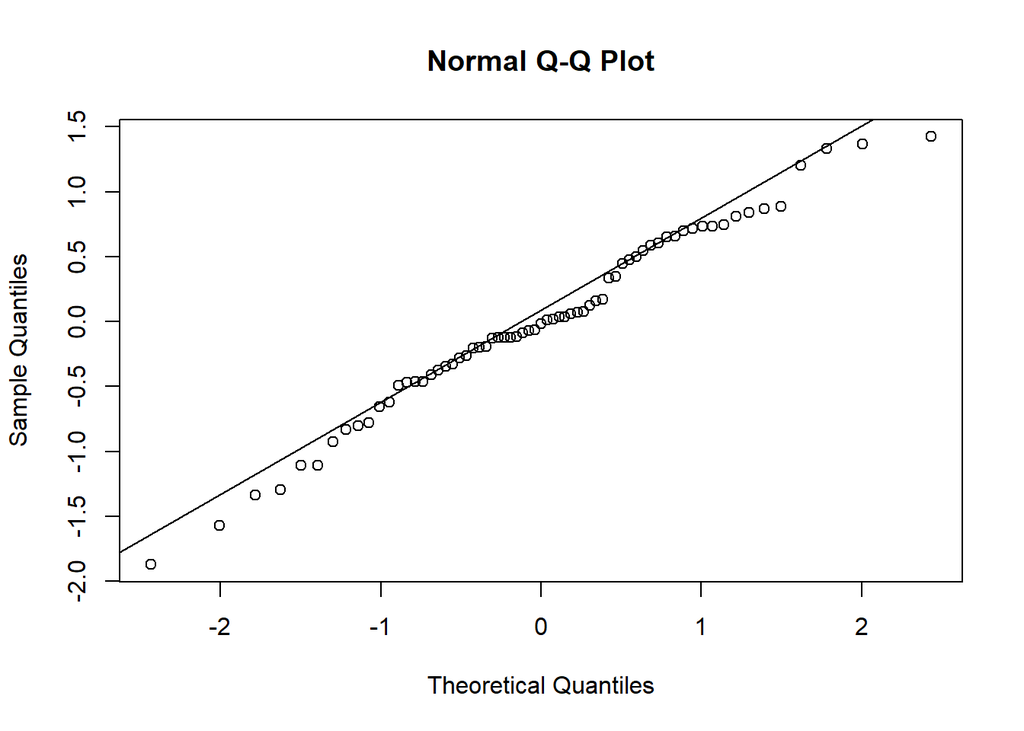

```r
qqnorm(significantPredictors.lm$residuals)
qqline(significantPredictors.lm$residuals)
```

```r
AIC(significantPredictors.lm)
```

```
## [1] 154.3127
```

```r
AIC(allPredictors.lm)
```

```
## [1] 155.0101
```

```r
testPredict<-predict(significantPredictors.lm,
                     newdata = prostateData.norm.test[,-c(3,6,7,8,9,10)])
testOutput<-prostateData.norm.test$lpsa
(MSE.significantPredictors<-mean((testOutput-testPredict)^2))
```

```
## [1] 0.4563321
```

```r
testPredict.mean<-mean(prostateData.norm.train$lpsa)          # null model
(MSE.meanPredictor<-mean((testOutput-testPredict.mean)^2))
```

```
## [1] 1.056733
```

Using both AIC and mean square prediction error as measures of goodness of fit we show that the model with only significant predictors is better than the model with all predictors.

The last MSE value is for the null model.

### 2.1.3 Lasso regression model

Create a train matrix $X$ with only inputs and train vector $Y$ of outputs.

```r
X<-data.matrix(prostateData.norm.train[,1:8])
Y<-prostateData.norm.train[,9]
```

Fit lasso regression model to train data.

Parameter `alpha` switches between ridge regression (0) and lasso regression (1).  
Argument `nlambda` is the number of `lambda` values in the selection process.  
Argument `lambda.min.ratio` is Smallest value for `lambda`, as a fraction of `lambda.max`.  
No need to standardize because we have done standardization outside.

```r
lassoProstate=glmnet(x=X,y=Y,alpha=1,nlambda=100,lambda.min.ratio=.0001,standardize = F)
names(lassoProstate)
```

```
##  [1] "a0"        "beta"      "df"        "dim"       "lambda"    "dev.ratio"
##  [7] "nulldev"   "npasses"   "jerr"      "offset"    "call"      "nobs"
```

```r
head(cbind(DF=lassoProstate$df,DevRatio=lassoProstate$dev.ratio,Lambda=lassoProstate$lambda))
```

```
##      DF   DevRatio    Lambda
## [1,]  0 0.00000000 0.9196376
## [2,]  1 0.09126085 0.8379396
## [3,]  1 0.16702722 0.7634993
## [4,]  1 0.22992978 0.6956721
## [5,]  1 0.28215260 0.6338705
## [6,]  1 0.32550890 0.5775592
```

Parameter `df` returned by `glmnet()` is the number of active predictors at the corresponding level of `lambda`.  
Parameter `dev.ratio` shows percent of deviance explained.

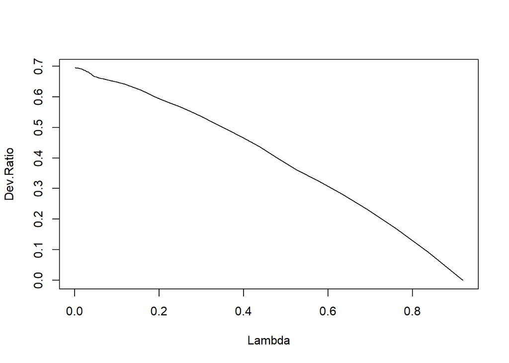

```r
plot(lassoProstate$lambda,lassoProstate$dev.ratio,type="l",
     ylab="Dev.Ratio",xlab="Lambda")
```

This plot shows how explained deviance (%) grows as $\lambda$ becomes smaller.

The following plot shows trajectories of coefficients as $L_1$-norm changes, where $L_1$-norm is $|| \mathbf{\beta}||=\sum_i |\beta_i|$.

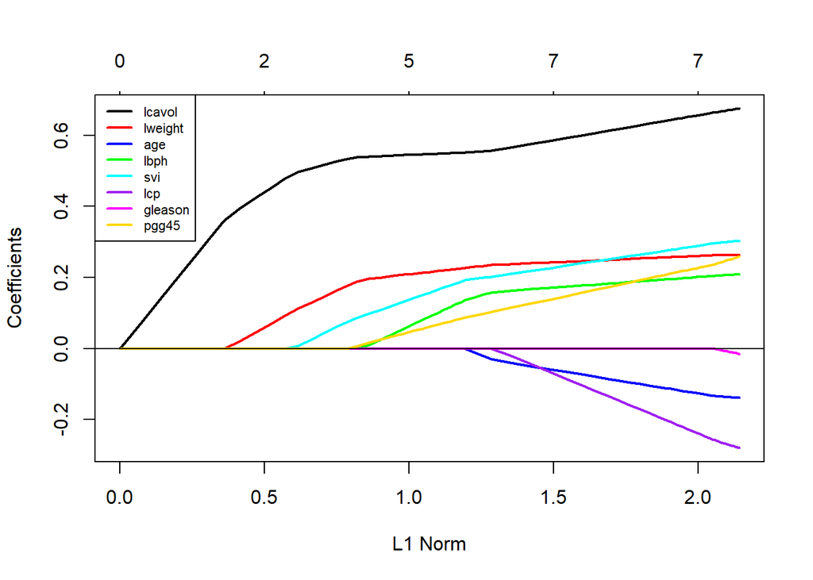

```r
plot(lassoProstate,col=c("black","red","blue","green","cyan","purple","magenta","gold"),lwd=2)
abline(h=0)
legend("topleft",legend=c("lcavol","lweight","age","lbph","svi","lcp","gleason","pgg45"),
       col=c("black","red","blue","green","cyan","purple","magenta","gold"),lty=1,lwd=2,cex=.7)
```

The graph shows how coefficients become small and turn into zeros one by one as $L_1$-norm decreases.

Next, use cross validation to find the best level of $\lambda$.

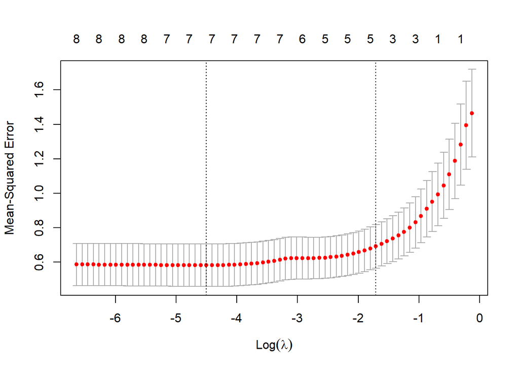

```r
set.seed(15)
cv.out=cv.glmnet(x=X,y=Y,alpha=1)
plot(cv.out)
```

The plot shows how mean square error changes with $\lambda$.  
Vertical intervals are standard deviation bounds for mean square error.  
Left vertical line shows the best parameter $\lambda$, the vertical line on the right is one standard deviation away.  
The best $\lambda$ is returned by `cv.glmnet()`.

We see that standard errors of each MSE coded by red dots are pretty wide and the difference between $\lambda_{min}$ and $\lambda_{min}+\sigma_{\lambda}$ is pretty wide also.  
These are the signs that model may not be working very well for this data set.  
The lambda minimizing the mean cross-validated error is returned as `$lambda.min`.

```r
(bestlam =cv.out$lambda.min)
```

```
## [1] 0.01109021
```

Predict the output of the test sample using the model fitted to the train sample and calculate mean square prediction error.

```r
lasso.pred=predict(lassoProstate,s=bestlam,
                   newx=data.matrix(prostateData.norm.test[,1:8]))
(MSE.lasso<-mean((lasso.pred -testOutput)^2))
```

```
## [1] 0.4969871
```

Finally, use the best $\lambda$ to fit the model to the entire sample.

```r
out=glmnet(x=as.matrix(prostateData.norm[,1:8]),y=as.vector(prostateData.norm[,9]),alpha=1,lambda=bestlam,standardize=F)
```

Find lasso coefficients and compare them with the coefficients of linear model

```r
lasso.coef=predict(lassoProstate,type="coefficients",s=bestlam)
cbind(Lasso=lasso.coef[,1],Lm=as.vector(allPredictors.lm$coefficients))
```

```
##                  Lasso          Lm
## (Intercept)  0.1725463  0.42917013
## lcavol       0.6477941  0.67952814
## lweight      0.2581969  0.26305307
## age         -0.1177961 -0.14146483
## lbph         0.1973938  0.21014656
## svi          0.2817490  0.30520060
## lcp         -0.2176740 -0.28849277
## gleason      0.0000000 -0.02130504
## pgg45        0.2163031  0.26695576
```

As expected, predictor `gleason` was eliminated.

Compare mean square prediction errors:

```r
c(Null=MSE.meanPredictor,Linear=MSE.significantPredictors,Lasso=MSE.lasso)
```

```
##      Null    Linear     Lasso
## 1.0567332 0.4563321 0.4969871
```

### 2.1.4 PCA

Apply the PCA method to the same data using function `princomp()`.  
The final outputs below are obtained using 5 best PCA factors as predictors in linear model.

- Run PCA
- Extract factors and loadings
- Fit linear model using meta-features
- Apply `relimp()`, observe the ranks of meta features
- Reorder factors and loadings according to the ranks
- Calculate determination coefficients for increasing number of meta features
- Restore slopes of original features using 5 best meta features in linear model

(Skipped Code)

```r
# run PCA
prostateData.PCA<-princomp(data.matrix(prostateData.norm.train[,1:8]))
summary(prostateData.PCA)
```

```
## Importance of components:
##                           Comp.1    Comp.2    Comp.3     Comp.4     Comp.5
## Standard deviation     1.8782384 1.3264417 1.0328897 0.78798938 0.71149393
## Proportion of Variance 0.4234154 0.2111745 0.1280481 0.07452567 0.06075857
## Cumulative Proportion  0.4234154 0.6345899 0.7626379 0.83716361 0.89792218
##                            Comp.6     Comp.7     Comp.8
## Standard deviation     0.62801428 0.52783278 0.42127750
## Proportion of Variance 0.04733738 0.03343935 0.02130108
## Cumulative Proportion  0.94525956 0.97869892 1.00000000
```

```r
library(relaimpo)
# extract factors and loadings
nFactors<-8
factorLoadings<-prostateData.PCA$loadings[,1:nFactors]
factorScores<-prostateData.PCA$scores[,1:nFactors]
zeroLoading<-prostateData.PCA$center
# fit linear model using meta features
factors8Data<-data.frame(Y=prostateData.norm.train[,9],factorScores)
m8.PCA<-lm(Y~.,data=factors8Data)
# apply relimp(), observe the ranks of meta features
(metrics.PCA <- calc.relimp(m8.PCA, type = c("lmg","first")))
```

```
## Response variable: Y
## Total response variance: 1.45881
## Analysis based on 67 observations
##
## 8 Regressors:
## Comp.1 Comp.2 Comp.3 Comp.4 Comp.5 Comp.6 Comp.7 Comp.8
## Proportion of variance explained by model: 69.44%
## Metrics are not normalized (rela=FALSE).
##
## Relative importance metrics:
##
##                lmg       first
## Comp.1 0.472278997 0.472278997
## Comp.2 0.059001883 0.059001883
## Comp.3 0.067062277 0.067062277
## Comp.4 0.013331731 0.013331731
## Comp.5 0.007200766 0.007200766
## Comp.6 0.007755291 0.007755291
## Comp.7 0.039375751 0.039375751
## Comp.8 0.028364483 0.028364483
##
## Average coefficients for different model sizes:
##
##                1X        2Xs        3Xs        4Xs        5Xs        6Xs
## Comp.1  0.4386140  0.4386140  0.4386140  0.4386140  0.4386140  0.4386140
## Comp.2  0.2195223  0.2195223  0.2195223  0.2195223  0.2195223  0.2195223
## Comp.3  0.3005516  0.3005516  0.3005516  0.3005516  0.3005516  0.3005516
## Comp.4 -0.1756535 -0.1756535 -0.1756535 -0.1756535 -0.1756535 -0.1756535
## Comp.5  0.1429723  0.1429723  0.1429723  0.1429723  0.1429723  0.1429723
## Comp.6  0.1680983  0.1680983  0.1680983  0.1680983  0.1680983  0.1680983
## Comp.7  0.4506631  0.4506631  0.4506631  0.4506631  0.4506631  0.4506631
## Comp.8  0.4792400  0.4792400  0.4792400  0.4792400  0.4792400  0.4792400
##               7Xs        8Xs
## Comp.1  0.4386140  0.4386140
## Comp.2  0.2195223  0.2195223
## Comp.3  0.3005516  0.3005516
## Comp.4 -0.1756535 -0.1756535
## Comp.5  0.1429723  0.1429723
## Comp.6  0.1680983  0.1680983
## Comp.7  0.4506631  0.4506631
## Comp.8  0.4792400  0.4792400
```

```r
(first.PCA.rank<-metrics.PCA@first.rank)
```

```
## Comp.1 Comp.2 Comp.3 Comp.4 Comp.5 Comp.6 Comp.7 Comp.8
##      1      3      2      6      8      7      4      5
```

```r
# reorder factors and loadings according to the ranks
orderedFactors<-factorScores[,order(first.PCA.rank)]
orderedLoadings<-factorLoadings[,order(first.PCA.rank)]
colnames(orderedFactors)
```

```
## [1] "Comp.1" "Comp.3" "Comp.2" "Comp.7" "Comp.8" "Comp.4" "Comp.6" "Comp.5"
```

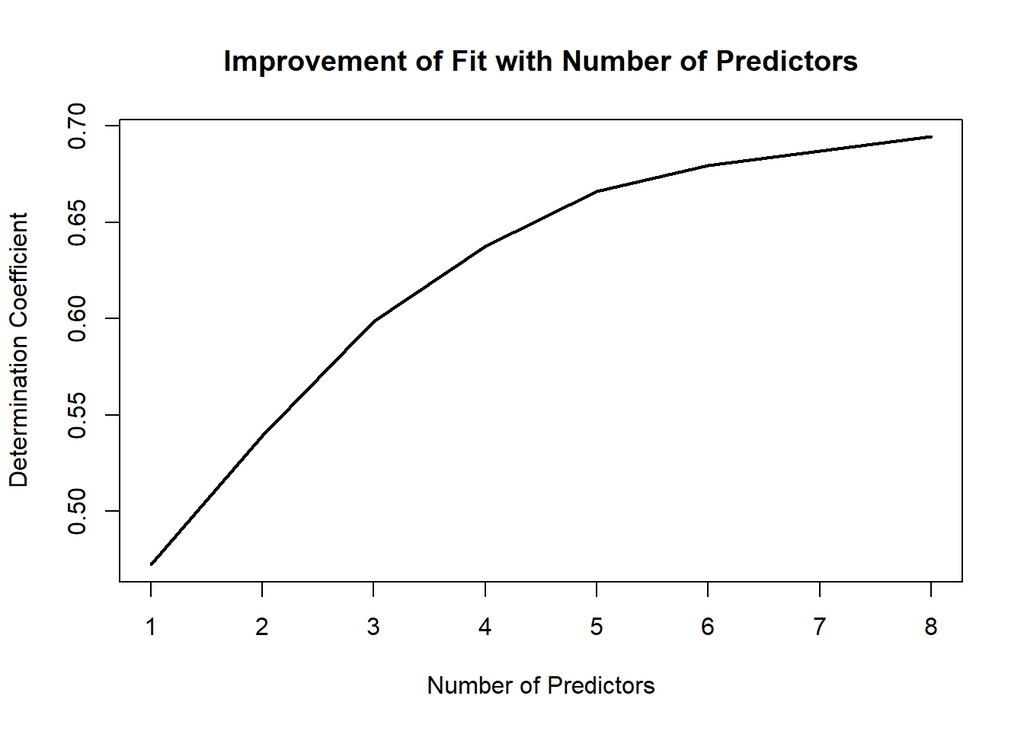

```r
# calculate determination coefficients for increasing number of meta features
orderedPCA.R2<-sapply(1:nFactors,function(z) summary(lm(Y~.,data=data.frame(Y=prostateData.norm.train[,9],orderedFactors[,1:z])))$r.squared)
plot(1:nFactors,orderedPCA.R2,type="l",lty=1,lwd=2,col=c("black","red","blue"),
        main="Improvement of Fit with Number of Predictors",xlab="Number of Predictors",ylab="Determination Coefficient")
```

```r
m5.PCA<-lm(Y~.,data=data.frame(Y=prostateData.norm.train[,9],orderedFactors[,1:5]))
# restore slopes of original features using 5 best meta features in linear model
coefficients.PCA<-m5.PCA$coefficients
restoredSlopes<-as.vector(orderedLoadings[,1:5]%*%coefficients.PCA[-1])
```

Compare coefficients returned by the lasso regression, linear model and PCA methods.

```r
coefficientsComparison<-cbind(Lasso=lasso.coef[-1],
                              Lm=t(as.vector(allPredictors.lm$coefficients))[-1],
                              PCR = restoredSlopes)
rownames(coefficientsComparison)<-c("lcavol","lweight","age","lbph","svi","lcp","gleason","pgg45")
coefficientsComparison
```

```
##              Lasso          Lm          PCR
## lcavol   0.6477941  0.67952814  0.524794956
## lweight  0.2581969  0.26305307  0.323933224
## age     -0.1177961 -0.14146483 -0.003454459
## lbph     0.1973938  0.21014656  0.093070145
## svi      0.2817490  0.30520060  0.434444710
## lcp     -0.2176740 -0.28849277 -0.322243369
## gleason  0.0000000 -0.02130504 -0.054506508
## pgg45    0.2163031  0.26695576  0.281249599
```

Note that the lasso model eliminated the smallest coefficient for predictor `gleason`, that predictor was also eliminated by the linear model fitted with significant predictors.  
PCR method used all original predictors, but if the number of factors is reduced to 5 the regression problem in fact has smaller number of predictors to fit.  
If all PCA factors are used as predictors then coefficients are expected to be the same as coefficients of the linear model.

Calculate MSE for PCR method:

1. With the test data calculate test meta features using definition of factors in PCR:
   $$F=X_0~L,$$
   where
- $X_0$ is the test matrix of the original features centered by the zero loading of the PCA model fitted to the train feature matrix
- $L$ is the matrix of loadings of the PCA model fitted to the train feature matrix
2. Reorder test meta features in the order of relative importance of factors of the PCA model fitted to the original features
3. Predict test response sample with the linear model containing the best 5 train meta features using test meta features as new data
4. Calculate MSE of the PCR model

(Skipped Code)

```r
# Create features
testFeatures<-(t(apply(prostateData.norm.test[,1:8],1,function(z) z-zeroLoading))%*%
                 factorLoadings)[,order(first.PCA.rank)][,1:5]
# Predict ml
testPredict<-predict(m5.PCA,
                     newdata =data.frame(Y=prostateData.norm.test[,9],testFeatures))
# Calculate MSE
testOutput<-prostateData.norm.test$lpsa
(MSE.PCR<-mean((testOutput-testPredict)^2))
```

```
## [1] 0.5755578
```

Compare all 4 models.

```r
c(Null=MSE.meanPredictor,Linear=MSE.significantPredictors,Lasso=MSE.lasso,PCR=MSE.PCR)
```

```
##      Null    Linear     Lasso       PCR
## 1.0567332 0.4563321 0.4969871 0.5755578
```

# 3 Using Ridge and Lasso regression with the large number of predictors

## 3.1 Simulation of the data

In this experiment simulate a series of nested linear models with large number of independent predictors.
The model is:
$$Y_{i,j} = \beta_0 + \beta_1
X_{i,1} + \ldots + \beta_{i,j} +
\epsilon_i;~~i=1,\ldots,500;~~j=2,\ldots,500.$$
So, the first model of the series, $j=2$ is
$$Y_{i,2} = \beta_0 + \beta_1 X_{i,1} + \beta_2
X_{i,2} + \epsilon_i;~~i=1,\ldots,500.$$
And the last model of the series, $j=500$ is
$$Y_{i,500} = \beta_0 + \beta_1 X_{i,1} + \ldots +
\beta_{i,500} + \epsilon_i;~~i=1,\ldots,500.$$
All nested models have the same vector of residuals $\epsilon_i;~~i=1,\ldots,500;\epsilon_i \sim Norm(0,1)$.
All 500 predictors $X_{i,j};~~j=1,\ldots,500$ are independent samples from $Norm(0,2).$
Slopes of the predictors are randomly selected from uniform distribution on $[1,3]$.

```r
set.seed(8394756)
Epsilon<-rnorm(500,0,1)
X<-rnorm(500*500,0,2)
dim(X)<-c(500,500)
colnames(X)<-paste0("X",1:500)
slopesSet<-runif(500,1,3)
Y<-sapply(2:500,function(z) 1+X[,1:z]%*%slopesSet[1:z]+Epsilon)
head(X[,1:5])
```

```
##              X1         X2          X3         X4         X5
## [1,]  0.3370062  0.6848857  2.06164948  2.4710729 -0.9210807
## [2,] -0.5542172  0.1313418  0.89297646 -2.2807232 -1.5143379
## [3,] -2.0782217  2.1293576 -0.09454899 -1.3202757  0.9659443
## [4,]  3.5666135 -0.7840215 -0.59791696  0.2582839  1.0351459
## [5,]  2.4998707 -1.7336962 -1.14667781  0.8764988  0.9090661
## [6,] -0.6179658 -2.7543016  3.65547139  0.7324393  4.7460823
```

```r
head(Y[,1:5])
```

```
##            [,1]       [,2]      [,3]      [,4]       [,5]
## [1,]  2.1820586  4.4465877  9.080900  7.183221  7.0524560
## [2,] -2.4813187 -1.5004676 -5.777793 -8.897745 -8.4374700
## [3,] -0.7942597 -0.8981129 -3.374191 -1.384081 -0.4922709
## [4,]  9.8513528  9.1945970  9.678989 11.811674 11.2109807
## [5,]  4.2901976  3.0306793  4.674487  6.547413  4.8575678
## [6,] -6.6256043 -2.6104110 -1.236776  8.541457 11.1407643
```

```r
head(Epsilon)
```

```
## [1] -1.2625103 -2.2939351 -1.0286555  1.0721695  0.5049569  0.2320966
```

```r
head(slopesSet,10)
```

```
##  [1] 2.676247 2.252430 1.098406 1.875425 2.060275 1.030717 1.646782 2.400179
##  [9] 1.009355 2.873308
```

## 3.2 Fitting linear models

Fit linear model with the first 10 predictors.

```r
m10<-lm(Y~.,data=data.frame(Y=Y[,9],X[,1:10]))
```

Fit linear model with 491 predictors.

```r
completeModelDataFrame<-data.frame(Y=Y[,490],X[,1:491])
m490<-lm(Y~.,data=completeModelDataFrame)
```

## 3.3 Ridge regression

Apply ridge regression to the data with 10 predictors.

```r
ridge10<-glmnet(x=X[,1:10],y=Y[,9],alpha=0,nlambda=200,lambda.min.ratio=.0001,standardize=F)
names(ridge10)
```

```
##  [1] "a0"        "beta"      "df"        "dim"       "lambda"    "dev.ratio"
##  [7] "nulldev"   "npasses"   "jerr"      "offset"    "call"      "nobs"
```

Separate the sample into `train` and `test`.

```r
set.seed(1)
train=sample (1:nrow(X[,1:10]), nrow(X[,1:10])/2)
test=(-train)
y.test=Y[test,9]
```

Select the best parameter $\lambda$ using cross validation on train set.  
Use the default ten-fold cross validation.

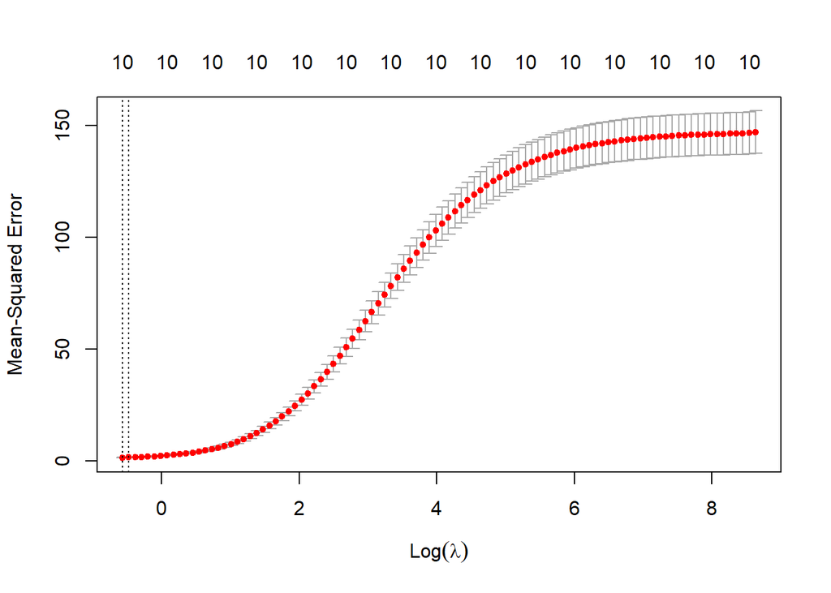

```r
set.seed(5)
cv.out=cv.glmnet(x=X[train,1:10],Y[train,9],alpha=0)
plot(cv.out)
```

```r
bestlam =cv.out$lambda.min
bestlam
```

```
## [1] 0.5644019
```

Calculate mean squared prediction error for the best selected $\lambda~=$ 0.5644019.

```r
ridge.pred=predict(ridge10,s=bestlam,newx=X[test,1:10])
(ridge.MSE<-mean((ridge.pred-y.test)^2))
```

```
## [1] 1.014893
```

Compare the mean squared prediction error of linear model

```r
train.m10<-lm(Y~.,data=data.frame(Y=Y[train,9],X[train,1:10]))
lm.pred<-predict(train.m10,newdata=as.data.frame(X[test,1:10]))
(lm.MSE<-mean((lm.pred-y.test)^2))
```

```
## [1] 1.011488
```

Regularization is expected to reduce number of predictors when there are collinear (highly correlated) predictors.  
Predictors in this example are not collinear.

## 3.4 Lasso regression

Fit lasso regression to the first 10 predictors.

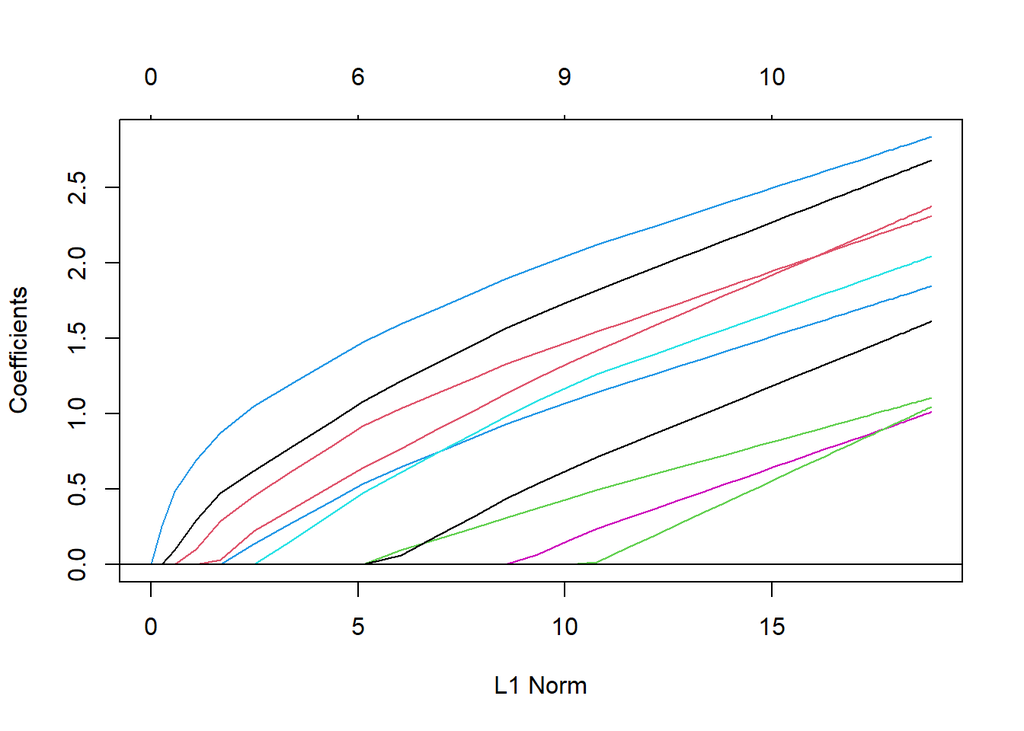

```r
lasso10=glmnet(x=data.matrix(X[train,1:10]),y=Y[train,9],alpha=1,nlambda=100,lambda.min.ratio=.0001)
plot(lasso10)
abline(h=0)
```

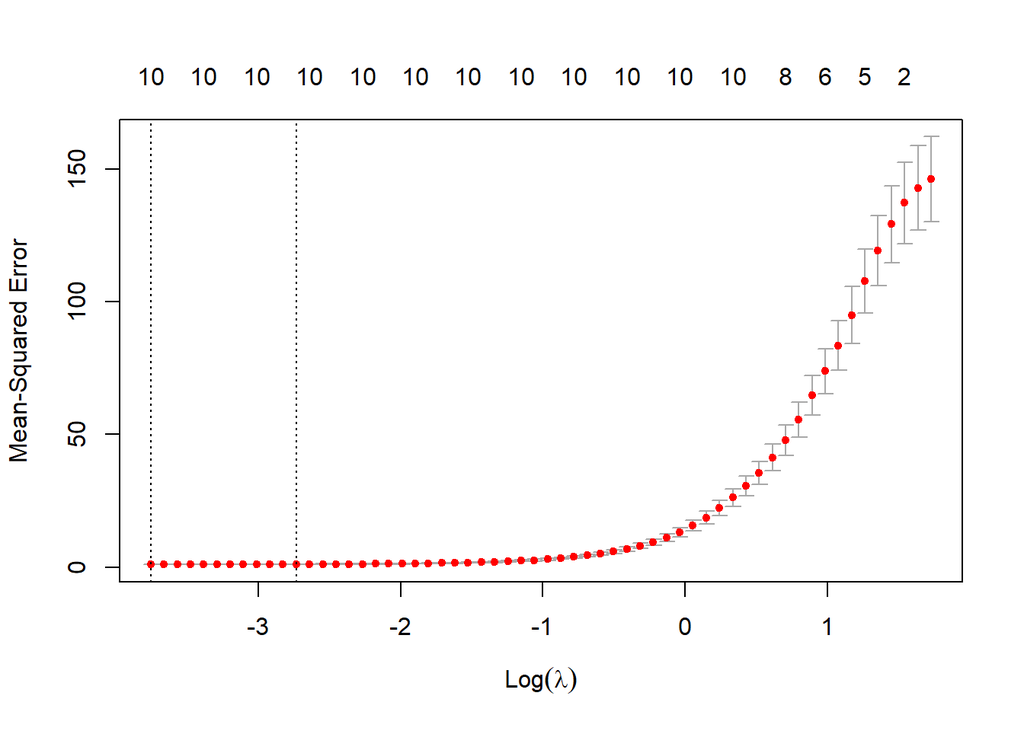

```r
set.seed(1)
cv.out=cv.glmnet(x=X[train,1:10],y=Y[train,9],alpha=1)
plot(cv.out)
```

```r
(bestlam =cv.out$lambda.min)
```

```
## [1] 0.02332116
```

```r
lasso.pred=predict(lasso10,s=bestlam,newx=X[test,1:10])
(lasso.MSE<-mean((lasso.pred -y.test)^2) )
```

```
## [1] 1.007118
```

Now fit the model to the entire data.

```r
out=glmnet(x=X[,1:10],y=Y[,9],alpha=1,nlambda=100,lambda.min.ratio=.0001)
lasso.coef=predict(out,type="coefficients",s=bestlam)
cbind(Lasso=lasso.coef,Lm=as.vector(m10$coefficients),Actual=c(1,slopesSet[1:10]))
```

```
## 11 x 3 sparse Matrix of class "dgCMatrix"
##                    s1       Lm   Actual
## (Intercept) 1.0000871 1.001312 1.000000
## X1          2.6727299 2.685284 2.676247
## X2          2.2815392 2.295926 2.252430
## X3          1.0790833 1.089440 1.098406
## X4          1.8454021 1.858704 1.875425
## X5          2.0613052 2.074314 2.060275
## X6          1.0198272 1.030915 1.030717
## X7          1.6419064 1.655600 1.646782
## X8          2.3759271 2.388937 2.400179
## X9          0.9876589 1.004436 1.009355
## X10         2.8181402 2.830665 2.873308
```

```r
c(LM=lm.MSE,Ridge=ridge.MSE,Lasso=lasso.MSE)
```

```
##       LM    Ridge    Lasso
## 1.011488 1.014893 1.007118
```

## 3.5 Large number of significant predictors

Apply lasso regression analysis to data with 490 predictors.

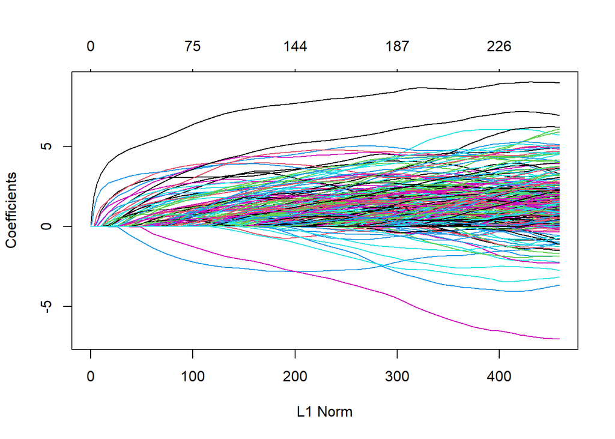

```r
y.test=Y[test,490]
lasso490=glmnet(x=X[train,1:491],y=Y[train,490],alpha=1,nlambda=100,lambda.min.ratio=.0001)
plot(lasso490)
```

Find best $\lambda$ using cross validation.

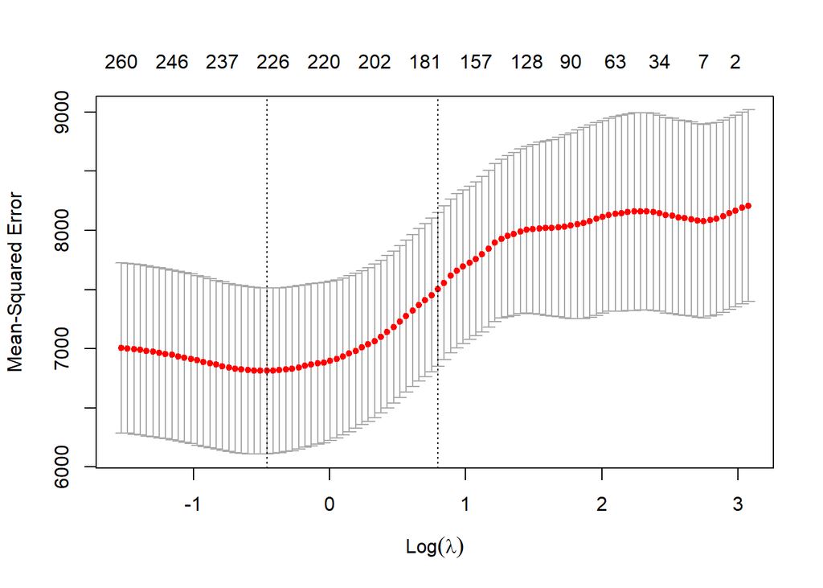

```r
cv.out=cv.glmnet(x=X[train,1:491],y=Y[train,490],alpha=1)
plot(cv.out)
```

```r
(bestlam =cv.out$lambda.min)
```

```
## [1] 0.6316232
```

```r
lasso.pred=predict(lasso490,s=bestlam,newx=X[test,1:491])
mean((lasso.pred -y.test)^2)
```

```
## [1] 6461.153
```

Fit lasso regression model to the entire data.  
Plot the set of true slopes used in simulation and mark slopes removed by lasso.

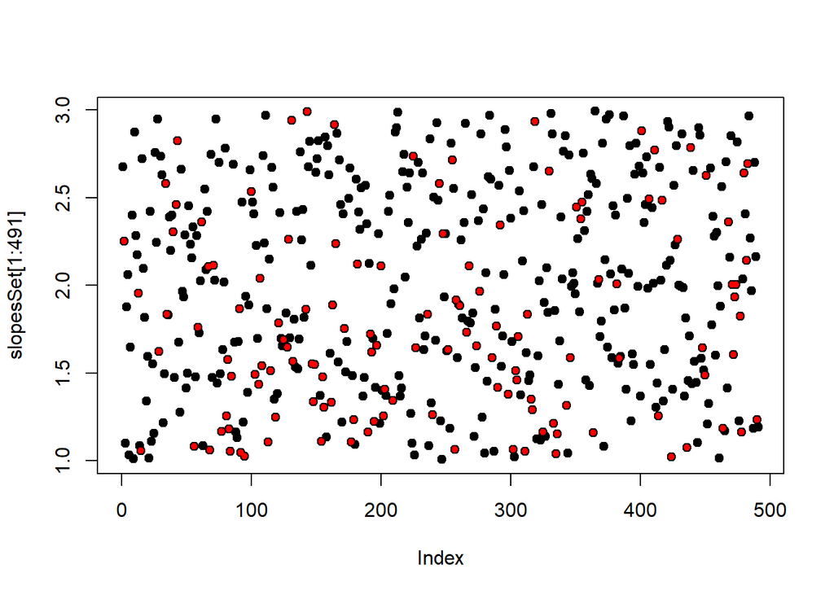

```r
out=glmnet(x=X[,1:491],y=Y[,490],alpha=1,lambda=bestlam)
lasso.coef=predict(out,type="coefficients",s=bestlam)
removedSlopes<-rep(NA,491)
removedSlopes[lasso.coef[-1]==0]<-slopesSet[1:491][lasso.coef[-1]==0]
plot(slopesSet[1:491],pch=19)
points(removedSlopes,col="red",pch=20)
```

Lasso removed predictors seemingly randomly regardless of the value of slope.  
Given the way the sample was simulated (independent predictors with slopes between 1 and 3) it would be more reasonable removing none or removing the predictors with smallest slopes.

## 3.6 Large number of predictors, not all of them are significant

To check how lasso regression removes predictors modify the simulated data to make some of predictors insignificant.

```r
set.seed(8394756)
Epsilon<-rnorm(500,0,1)
X<-rnorm(500*500,0,2)
dim(X)<-c(500,500)
colnames(X)<-paste0("X",1:500)
slopesSet<-runif(500,-.1,3)
```

The previous set was simulated with slopes randomly selected between 1 and 3.  
Such selection of slopes made them all distinct from zero which was captured by the linear model.  
Now select slopes as random numbers between -0.1 and 3.  
Obviously, the slopes which are close to zero should appear as insignificant in a model fit.

Continue simulating the sample.

```r
Y<-sapply(2:500,function(z) 1+X[,1:z]%*%slopesSet[1:z]+Epsilon)
head(X[,1:5])
```

```
##              X1         X2          X3         X4         X5
## [1,]  0.3370062  0.6848857  2.06164948  2.4710729 -0.9210807
## [2,] -0.5542172  0.1313418  0.89297646 -2.2807232 -1.5143379
## [3,] -2.0782217  2.1293576 -0.09454899 -1.3202757  0.9659443
## [4,]  3.5666135 -0.7840215 -0.59791696  0.2582839  1.0351459
## [5,]  2.4998707 -1.7336962 -1.14667781  0.8764988  0.9090661
## [6,] -0.6179658 -2.7543016  3.65547139  0.7324393  4.7460823
```

```r
head(Y[,1:5])
```

```
##           [,1]      [,2]      [,3]      [,4]      [,5]
## [1,]  1.840450  1.948748  5.054662  3.633042  3.639689
## [2,] -2.436635 -2.389727 -5.256388 -7.593656 -7.617051
## [3,] -1.299716 -1.304683 -2.964149 -1.473286 -1.518615
## [4,]  9.538627  9.507218  9.831858 11.429528 11.460060
## [5,]  4.557892  4.497657  5.599336  7.002412  7.088303
## [6,] -5.383099 -5.191077 -4.270467  3.054758  2.922641
```

```r
head(Epsilon)
```

```
## [1] -1.2625103 -2.2939351 -1.0286555  1.0721695  0.5049569  0.2320966
```

```r
head(slopesSet,10)
```

```
##  [1]  2.49818209  1.84126678  0.05253000  1.25690889  1.54342559 -0.05238902
##  [7]  0.90251277  2.07027782 -0.08549990  2.80362681
```

Separate the sample into train and test and fit lasso.

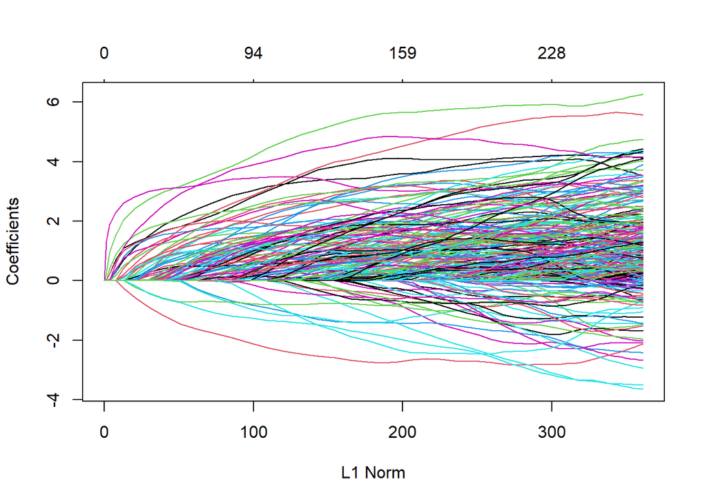

```r
y.test=Y[test,490]
lasso490=glmnet(x=X[train,1:491],y=Y[train,490],alpha=1,nlambda=100,lambda.min.ratio=.0001)
plot(lasso490)
```

Select best $\lambda$ using cross validation.

(Skipped Code)

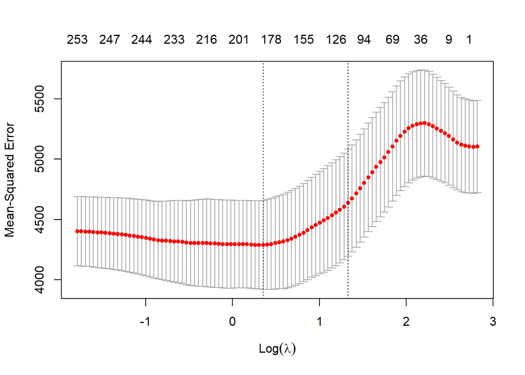

```r
set.seed(5)
cv.out=cv.glmnet(x=X[train,1:491],y=Y[train,490],alpha=1)
plot(cv.out)
```

```r
(bestlam =cv.out$lambda.min)
```

```
## [1] 1.421956
```

Fit lasso to the entire sample using best $\lambda$.

(Skipped Code)

```r
out=glmnet(x=X[,1:491],y=Y[,490],alpha=1,lambda=bestlam)
```

Find resulting coefficients.  
Plot actual slopes and mark the slopes removed by lasso.

(Skipped Code)

```r
lasso.coef=predict(out,type="coefficients",s=bestlam)
removedSlopes<-rep(NA,491)
removedSlopes[lasso.coef[-1]==0]<-slopesSet[1:491][lasso.coef[-1]==0]
```

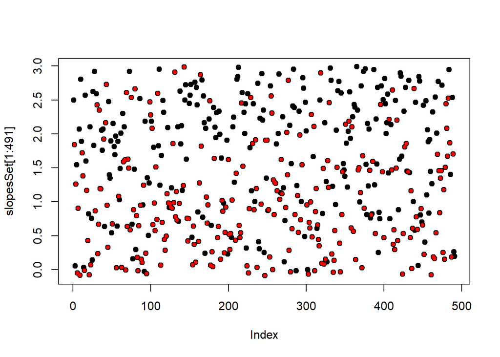

```r
plot(slopesSet[1:491],pch=19)
points(removedSlopes,col="red",pch=20)
```

Make the same plot marking actual slopes removed by linear model.

(Skipped Code)

```r
completeModelDataFrame<-data.frame(Y=Y[,490],X[,1:491])
m490<-lm(Y~.,data=completeModelDataFrame)
```

Check the coefficients that you obtained

```r
head(m490$coefficients,20)
```

```
## (Intercept)          X1          X2          X3          X4          X5
##  0.76942299  2.28807186  1.80751131  0.09601203  1.19022976  1.36330882
##          X6          X7          X8          X9         X10         X11
##  0.07404868  0.47967195  2.34535554 -0.18268692  3.10943722  2.08644882
##         X12         X13         X14         X15         X16         X17
##  1.71623022  1.28723419  0.08946153  0.06287955  2.58709475  1.55726447
##         X18         X19
##  1.07810288  0.32779733
```

Make plot showing slopes of removed predictors.

(Skipped Code)

```r
eliminatedByLm<-summary(m490)$coefficients[-1,4]>.05
removedSlopes<-rep(NA,491)
removedSlopes[eliminatedByLm]<-slopesSet[1:491][eliminatedByLm]
```

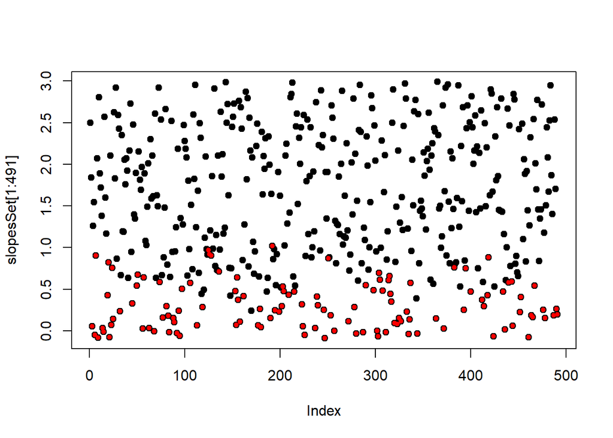

```r
plot(slopesSet[1:491],pch=19)
points(removedSlopes,col="red",pch=20)
```